# OLS Model

Quan Gan

2/9/2022

## load data in

There are three data sets with low, intermediate, and high errors.

```r
data_low <- read_csv("../Data/Dataset_S1_Mar8.csv")
data_intermediate <- read_csv("../Data/Dataset_S2_Apr20_V2.csv")
data_high <- read_csv("../Data/Dataset_S3_Apr20_V2.csv")
```

## The helper functions for bootstrapping 1000 replicates with OLS models and data visulization.

```r
# https://www.statmethods.net/advstats/bootstrapping.html
# Boot library docs
# calculate the coefficient
OLS_boot <- function(formula, data, indices) {
  d <- data[indices,]                                 # allows boot to select sample
  mark <- sample(                                     # Mark for train-test
    c(rep(0, 0.7*nrow(d)),
    c(rep(1, 0.3*nrow(d)))))
  train <- d[mark == 0,]                              # train data
  test <- d[mark == 1,]                               # test data
  fit <- lm(formula, data=train)                      # the OLS model
  train_MSE <- mean((train$D47 - predict(fit))^2)     # Train set MSE
  test_MSE <- mean((test$D47 - predict(fit, newdata = test))^2)# Test set MSE
  return(c(coef(fit), train_MSE, test_MSE))                    # get intercept
}

# The OLS function with bootstrapping
OLS <- function(seed, statistic, dataSet, formula, replicate){
  set.seed(seed)
  results <- boot(data = dataSet,
                  statistic = statistic,
                  R = replicate,
                  formula = formula)

  CI_Intecept <- boot.ci(results, type="bca", index=1)
  Intercept_names <- c("Median Intercept", "Intercept Std. Error", "2.5%", "92.5%")
  Intercept_values <- c(median(results$t[,1]), sd(results$t[,1]) / sqrt(length(results$t[,1])), CI_Intecept$bca[4], CI_Intecept$bca[5])
  names(Intercept_values) <- Intercept_names

  CI_Slope <- boot.ci(results, type="bca", index=2)
  Slope_names <- c("Median Slope", "Slope Std. Error", "2.5%", "92.5%")
  Slope_values <- c(median(results$t[,2]), sd(results$t[,2]) / sqrt(length(results$t[,2])), CI_Slope$bca[4], CI_Slope$bca[5])
  names(Slope_values) <- Slope_names

  MSE_names <- c("Median Train MSE", "Median Test MSE")
  MSE_values <- c(median(results$t[,3]), median(results$t[,4]))
  names(MSE_values) <- MSE_names


  Intercept_values %>% kable()
  Slope_values %>% kable()
  MSE_values %>% kable()

  return (c(Intercept_values, Slope_values, MSE_values))
}

# create data visualization
createPlot <- function(data, result, title, caption) {
  plot_object <- data %>%
    ggplot(aes(x = x_TRUE, y=y_TRUE)) +
    geom_ribbon(aes(ymin = result[7] * x_TRUE + result[4] , ymax = result[8] * x_TRUE + result[3]), fill = "orange") +
    geom_point() +
    geom_abline(slope = 0.0369, intercept = 0.268, color = 'red') +
    geom_abline(slope = result[5], intercept = result[1], color = 'yellow') +
    labs(title = title,
         caption = paste(caption, "\n", greeks("alpha"), "=",round(result[1], 4), "(95% CI", round(result[3], 4),"-", round(result[4],4), ")\n"
         , greeks("beta"), "=",round(result[5], 4), "(95% CI", round(result[7], 4),"-", round(result[8],4), ")" ))+
    xlab(expression(paste("True Temperature in ", ""^"o", "K"))) +
    ylab(expression(paste("True D47 (", ""^"o", "/"["oo"], ")")))
  return(plot_object)
}
```

## Low error bootstrapping results

```r
result_low <- OLS(3, OLS_boot, data_low, D47~Temperature, 1000)

rbind(result_low) %>% kable()
```

|  | Median Intercept | Intercept Std. Error | 2.5% | 92.5% | Median Slope | Slope Std. Error | 2.5% | 92.5% | Median Train MSE | Median Test MSE |
| --- | --- | --- | --- | --- | --- | --- | --- | --- | --- | --- |
| result_low | 0.2639036 | 7.2e-05 | 0.2614051 | 0.2701681 | 0.0371976 | 5.8e-06 | 0.0365961 | 0.0373233 | 0.0001588 | 0.0001592 |

### Comparing result to the true parameters

Plot confident interval area of the median slope/intercept of bootstrapping results And comparing it to the true slope/intercept

I use the true data points to plot.

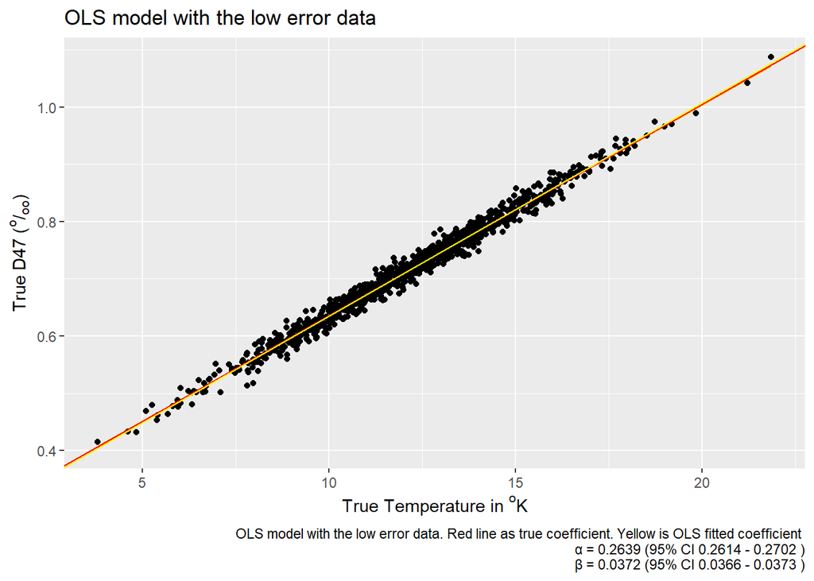

```r
plot_low <- createPlot(data_low,
           result_low,
           "OLS model with the low error data",
           "OLS model with the low error data. Red line as true coefficient. Yellow is OLS fitted coefficient" )

plot_low
```

## Intermediate error bootstrapping results

```r
result_intermediate <- OLS(3, OLS_boot, data_intermediate, D47~Temperature, 1000)

rbind(result_intermediate) %>% kable()
```

|  | Median Intercept | Intercept Std. Error | 2.5% | 92.5% | Median Slope | Slope Std. Error | 2.5% | 92.5% | Median Train MSE | Median Test MSE |
| --- | --- | --- | --- | --- | --- | --- | --- | --- | --- | --- |
| result_intermediate | 0.2703153 | 0.0001453 | 0.2623158 | 0.2803176 | 0.0367133 | 1.17e-05 | 0.0360586 | 0.0375039 | 0.0005503 | 0.0005574 |

### Comparing result to the true parameters

Plot confident interval area of the median slope/intercept of bootstrapping results And comparing it to the true slope/intercept

I use the true data points to plot.

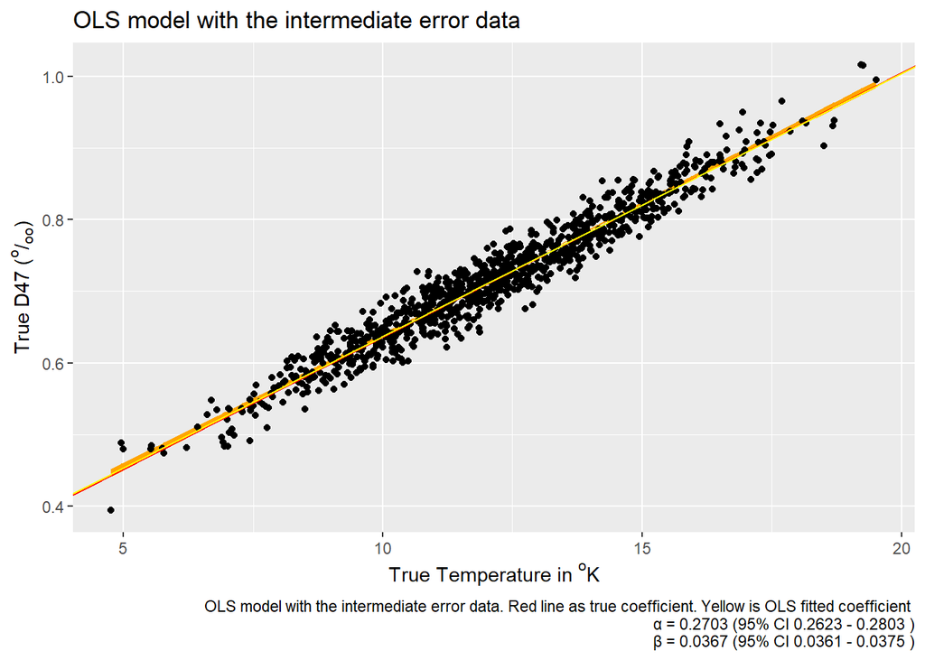

```r
plot_intermediate <- createPlot(data_intermediate,
           result_intermediate,
           "OLS model with the intermediate error data",
           "OLS model with the intermediate error data. Red line as true coefficient. Yellow is OLS fitted coefficient")

plot_intermediate
```

## High error bootstrapping results

```r
result_high <- OLS(3, OLS_boot, data_high, D47~Temperature, 1000)

rbind(result_high) %>% kable()
```

|  | Median Intercept | Intercept Std. Error | 2.5% | 92.5% | Median Slope | Slope Std. Error | 2.5% | 92.5% | Median Train MSE | Median Test MSE |
| --- | --- | --- | --- | --- | --- | --- | --- | --- | --- | --- |
| result_high | 0.2635987 | 0.0001582 | 0.2579681 | 0.2780055 | 0.0373017 | 1.3e-05 | 0.0364086 | 0.0379911 | 0.0009424 | 0.0009449 |

### Comparing result to the true parameters

Plot confident interval area of the median slope/intercept of bootstrapping results And comparing it to the true slope/intercept

I use the true data points to plot.

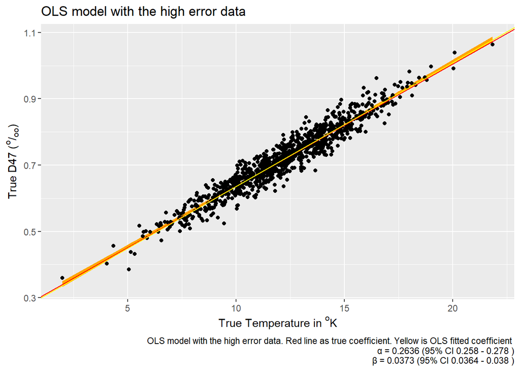

```r
plot_high <- createPlot(data_high,
           result_high,
           "OLS model with the high error data",
           "OLS model with the high error data. Red line as true coefficient. Yellow is OLS fitted coefficient")

plot_high
```

## Results across different data sets

```r
rbind(result_low, result_intermediate, result_high) %>% kable()
```

|  | Median Intercept | Intercept Std. Error | 2.5% | 92.5% | Median Slope | Slope Std. Error | 2.5% | 92.5% | Median Train MSE | Median Test MSE |
| --- | --- | --- | --- | --- | --- | --- | --- | --- | --- | --- |
| result_low | 0.2639036 | 0.0000720 | 0.2614051 | 0.2701681 | 0.0371976 | 5.80e-06 | 0.0365961 | 0.0373233 | 0.0001588 | 0.0001592 |
| result_intermediate | 0.2703153 | 0.0001453 | 0.2623158 | 0.2803176 | 0.0367133 | 1.17e-05 | 0.0360586 | 0.0375039 | 0.0005503 | 0.0005574 |
| result_high | 0.2635987 | 0.0001582 | 0.2579681 | 0.2780055 | 0.0373017 | 1.30e-05 | 0.0364086 | 0.0379911 | 0.0009424 | 0.0009449 |

By the OLS model, we could know when there is a low error in the data. The OLS could produce the slope and intercept close to the true parameters but with the increment of error, the OLS model would be less precise and accurate to predict the relationship between D47 and temperature.